# Biostat 212a Homework 4

Due Mar. 5, 2024 @ 11:59PM

Author

Yuhui Wang, UID: 606332401

Published

March 5, 2024

```r
library(ggplot2)
library(tidymodels)
library(tidyverse)
library(ape)
library(ggtree)
library(ISLR2)
library(gtsummary)
library(GGally)
library(ranger)
library(cli)
library(xgboost)
```

## 1 ISL Exercise 8.4.3 (10pts)

> Consider the Gini index, classification error, and cross-entropy in a simple classification setting with two classes. Create a single plot that displays each of these quantities as a function of $\hat{p}_{m1}$. The $x$-axis should display $\hat{p}_{m1}$, ranging from 0 to 1, and the $y$-axis should display the value of the Gini index, classification error, and entropy.

> *Hint: In a setting with two classes, $\hat{p}_{m1} = 1 - \hat{p}_{m2}$. You could make this plot by hand, but it will be much easier to make in `R`.*

**Answer:** Gini index is defined as:
$$G = \sum_{k=1}^{K} \hat{p}_{mk}(1 - \hat{p}_{mk})$$
for binary setting, it is: $G = 2\hat{p}_{m1}(1 - \hat{p}_{m1})$

Cross-entropy is defined as:
$$D = -\sum_{k=1}^{K} \hat{p}_{mk}\log(\hat{p}_{mk})$$
for binary setting, it is: $D = -\hat{p}_{m1}\log(\hat{p}_{m1}) - (1 - \hat{p}_{m1})\log(1 - \hat{p}_{m1})$

Classification error is defined as:
$$E = 1 - \max_k(\hat{p}_{mk})$$
for binary setting, it is: $E = 1 - \max(\hat{p}_{m1}, 1 - \hat{p}_{m1})$

Then, we can plot:

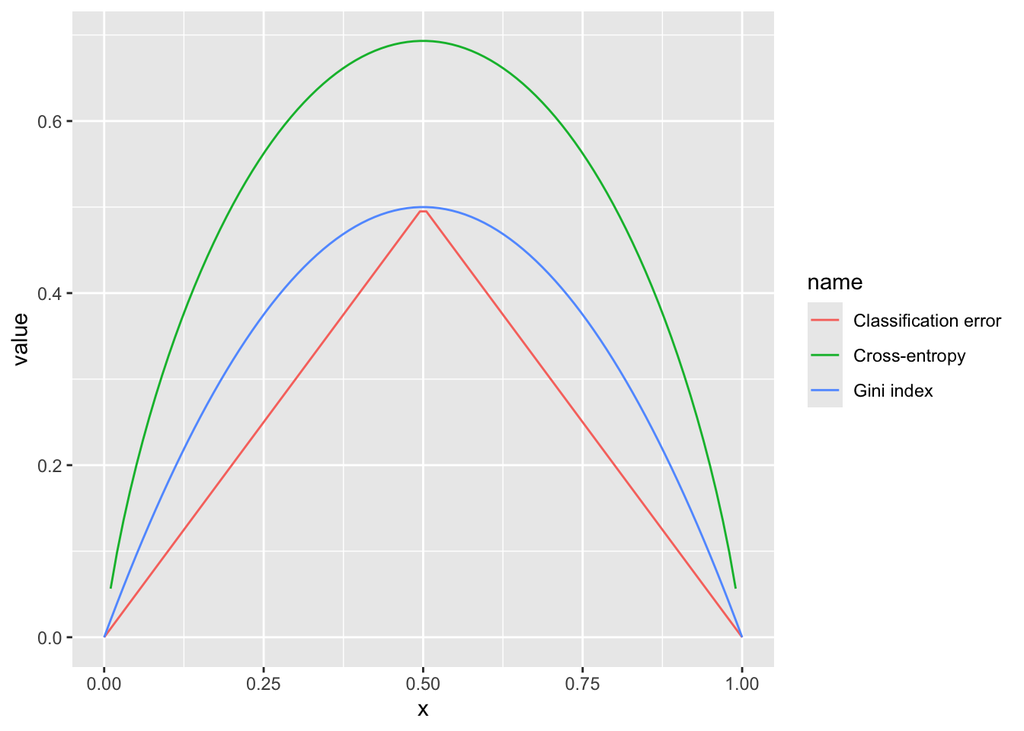

```r
p <- seq(0, 1, length.out = 100)

df <- data.frame(
    x = p,
    "Gini index" = p * (1 - p) * 2,
    "Cross-entropy" = -(p * log(p) + (1 - p) * log(1 - p)),
    "Classification error" = 1 - pmax(p, 1 - p),
    check.names = FALSE
  )

df |> pivot_longer(!x) |>
  ggplot(aes(x = x, y = value, color = name)) +
    geom_line(na.rm = TRUE)
```

## 2 ISL Exercise 8.4.4 (10pts)

> This question relates to the plots in Figure 8.14.
> 1. Sketch the tree corresponding to the partition of the predictor space illustrated in the left-hand panel of Figure 8.14. The numbers inside the boxes indicate the mean of $Y$ within each region.

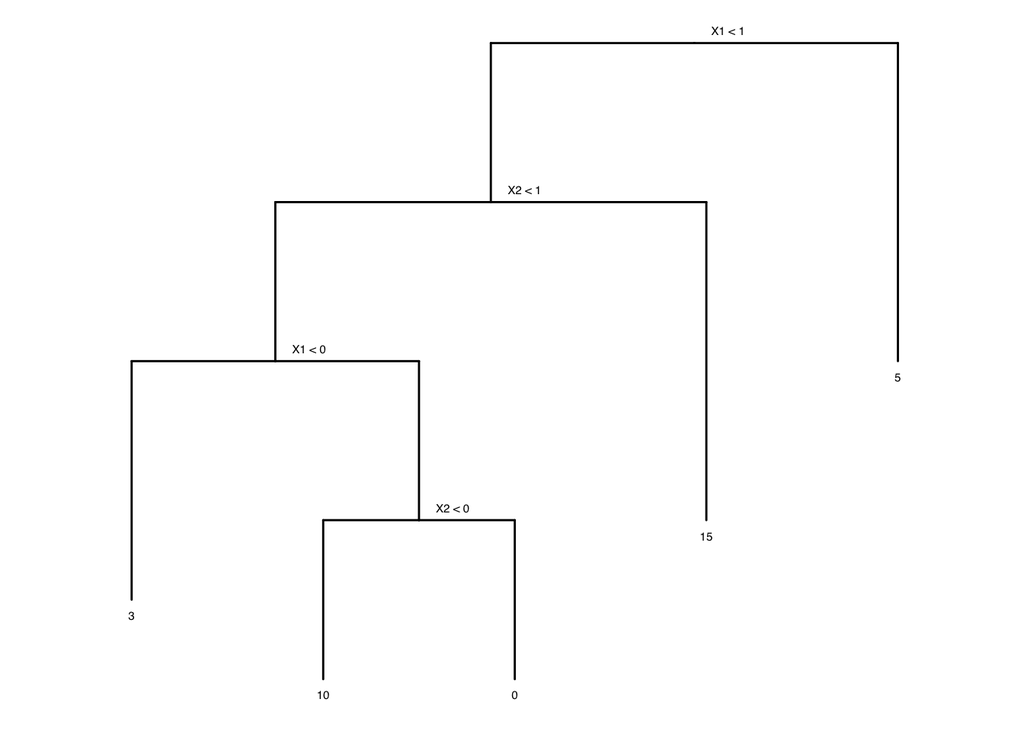

```r
#Add tree content
tree_content <- "(((3:1.5,(10:1,0:1)A:1)B:1,15:2)C:1,5:2)D;"
tree_8.14 <- ape::read.tree(text = tree_content)
tree_8.14$node.label <- c("X1 < 1", "X2 < 1", "X1 < 0", "X2 < 0")

#Plot
ggtree(tree_8.14, ladderize = FALSE) + scale_x_reverse() + coord_flip() +
  geom_tiplab(vjust = 2, hjust = 0.5, size = 2) +
  geom_text2(aes(label=label, subset=!isTip), hjust = -0.5, vjust = -1, size = 2)
```

> 2. Create a diagram similar to the left-hand panel of Figure 8.14, using the tree illustrated in the right-hand panel of the same figure. You should divide up the predictor space into the correct regions, and indicate the mean for each region.

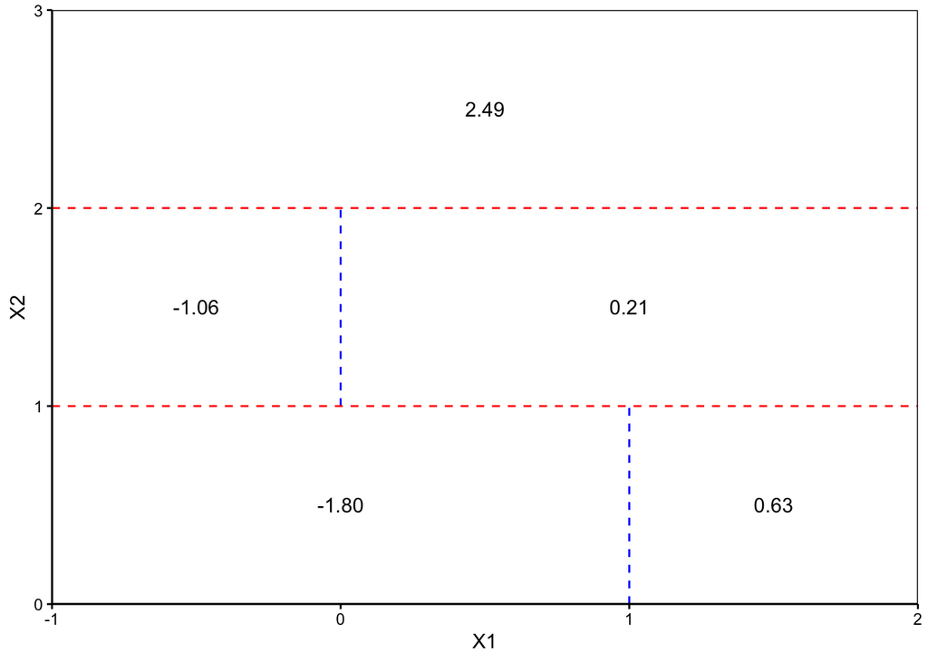

```r
lines_data <- data.frame(
  x = c(1, -1, 0, -1),
  xend = c(1, 2, 0, 2),
  y = c(0, 2, 1, 1),
  yend = c(1, 2, 2, 1),
  col = c("blue", "red", "blue", "red"),
  lty = c("dashed", "dashed", "dashed", "dashed")
)

texts_data <- data.frame(
  x = c(0, 1.5, -0.5, 1, 0.5),
  y = c(0.5, 0.5, 1.5, 1.5, 2.5),
  label = c("-1.80", "0.63", "-1.06", "0.21", "2.49")
)

ggplot() +
  geom_segment(data = lines_data, aes(x = x, y = y, xend = xend, yend = yend, colour = col, linetype = lty)) +
  geom_text(data = texts_data, aes(x = x, y = y, label = label)) +
  scale_x_continuous(name = "X1", limits = c(-1, 2), expand = c(0, 0)) +
  scale_y_continuous(name = "X2", limits = c(0, 3), expand = c(0, 0)) +
  theme_minimal() +
  theme(
    panel.grid = element_blank(),
    panel.border = element_rect(colour = "black", fill = NA, size = 0.5),
    axis.line = element_line(color = "black"),
    axis.ticks = element_line(color = "black"),
    axis.text = element_text(color = "black"),
    legend.position = "none"
  ) +
  guides(colour = FALSE, linetype = FALSE) +
  scale_color_identity() +
  scale_linetype_identity()
```

## 3 ISL Exercise 8.4.5 (10pts)

> Suppose we produce ten bootstrapped samples from a data set containing red and green classes. We then apply a classification tree to each bootstrapped sample and, for a specific value of $X$, produce 10 estimates of $P(\textrm{Class is Red}|X)$:
> $$0.1, 0.15, 0.2, 0.2, 0.55, 0.6, 0.6, 0.65, 0.7, \textrm{and } 0.75.$$
> There are two common ways to combine these results together into a single class prediction. One is the majority vote approach discussed in this chapter. The second approach is to classify based on the average probability. In this example, what is the final classification under each of these two approaches?

```r
p <- c(0.1, 0.15, 0.2, 0.2, 0.55, 0.6, 0.6, 0.65, 0.7, 0.75)
```

For majority vote:

```r
# majority vote
print(ifelse(mean(p > 0.5), "red", "green"))
```

```
[1] "red"
```

For average probability:

```r
# average probability
print(ifelse(mean(p) > 0.5, "red", "green"))
```

```
[1] "green"
```

## 4 ISL Lab 8.3. `Boston` data set (30pts)

Follow the machine learning workflow to train regression tree, random forest, and boosting methods for predicting `medv`. Evaluate out-of-sample performance on a test set.

```r
Boston <- Boston %>% filter(!is.na(medv))
```

Initial split into test and non-test sets:

```r
set.seed(1)
data_split <- initial_split(
  Boston,
  prop = 0.9
  )
data_split
```

```
<Training/Testing/Total>
<455/51/506>
```

```r
Boston_other <- training(data_split)
dim(Boston_other)
```

```
[1] 455  13
```

```r
Boston_test <- testing(data_split)
dim(Boston_test)
```

```
[1] 51 13
```

Recipe for R:

```r
tree_recipe <-
  recipe(
    medv ~ .,
    data = Boston_other
  ) %>%
  step_dummy(all_nominal()) %>%
  step_naomit(medv) %>%
  step_zv(all_numeric_predictors()) %>%
  step_normalize(all_numeric_predictors())

tree_recipe
```

Model

**Regression tree:**

```r
regtree_mod <- decision_tree(
  cost_complexity = tune(),
  tree_depth = tune(),
  min_n = 5,
  mode = "regression",
  engine = "rpart"
  )
regtree_mod
```

```
Decision Tree Model Specification (regression)

Main Arguments:
  cost_complexity = tune()
  tree_depth = tune()
  min_n = 5

Computational engine: rpart
```

Workflow

```r
tree_wf_rt <- workflow() %>%
  add_recipe(tree_recipe) %>%
  add_model(regtree_mod)
tree_wf_rt
```

```
══ Workflow ════════════════════════════════════════════════════════════════════
Preprocessor: Recipe
Model: decision_tree()

── Preprocessor ────────────────────────────────────────────────────────────────
4 Recipe Steps

• step_dummy()
• step_naomit()
• step_zv()
• step_normalize()

── Model ───────────────────────────────────────────────────────────────────────
Decision Tree Model Specification (regression)

Main Arguments:
  cost_complexity = tune()
  tree_depth = tune()
  min_n = 5

Computational engine: rpart
```

Tuning grid

```r
tree_grid <- grid_regular(cost_complexity(),
                          tree_depth(),
                          levels = c(100, 5))
```

Cross-validation

```r
# Set cross-validation partitions
set.seed(1)
folds <- vfold_cv(Boston_other, v = 5)
folds
```

```
#  5-fold cross-validation
# A tibble: 5 × 2
  splits           id
  <list>           <chr>
1 <split [364/91]> Fold1
2 <split [364/91]> Fold2
3 <split [364/91]> Fold3
4 <split [364/91]> Fold4
5 <split [364/91]> Fold5
```

```r
# Fit cross-validation
tree_fit <- tree_wf_rt %>%
  tune_grid(
    resamples = folds,
    grid = tree_grid,
    metrics = metric_set(rmse, rsq)
    )
tree_fit
```

```
# Tuning results
# 5-fold cross-validation
# A tibble: 5 × 4
  splits           id    .metrics             .notes
  <list>           <chr> <list>               <list>
1 <split [364/91]> Fold1 <tibble [1,000 × 6]> <tibble [0 × 3]>
2 <split [364/91]> Fold2 <tibble [1,000 × 6]> <tibble [0 × 3]>
3 <split [364/91]> Fold3 <tibble [1,000 × 6]> <tibble [0 × 3]>
4 <split [364/91]> Fold4 <tibble [1,000 × 6]> <tibble [0 × 3]>
5 <split [364/91]> Fold5 <tibble [1,000 × 6]> <tibble [0 × 3]>
```

```
# A tibble: 1,000 × 8
   cost_complexity tree_depth .metric .estimator  mean     n std_err
             <dbl>      <int> <chr>   <chr>      <dbl> <int>   <dbl>
 1        1   e-10          1 rmse    standard   7.30      5  0.342
 2        1   e-10          1 rsq     standard   0.386     5  0.0573
 3        1.23e-10          1 rmse    standard   7.30      5  0.342
 4        1.23e-10          1 rsq     standard   0.386     5  0.0573
 5        1.52e-10          1 rmse    standard   7.30      5  0.342
 6        1.52e-10          1 rsq     standard   0.386     5  0.0573
 7        1.87e-10          1 rmse    standard   7.30      5  0.342
 8        1.87e-10          1 rsq     standard   0.386     5  0.0573
 9        2.31e-10          1 rmse    standard   7.30      5  0.342
10        2.31e-10          1 rsq     standard   0.386     5  0.0573
   .config
   <chr>
 1 Preprocessor1_Model001
 2 Preprocessor1_Model001
 3 Preprocessor1_Model002
 4 Preprocessor1_Model002
 5 Preprocessor1_Model003
 6 Preprocessor1_Model003
 7 Preprocessor1_Model004
 8 Preprocessor1_Model004
 9 Preprocessor1_Model005
10 Preprocessor1_Model005
# ℹ 990 more rows
```

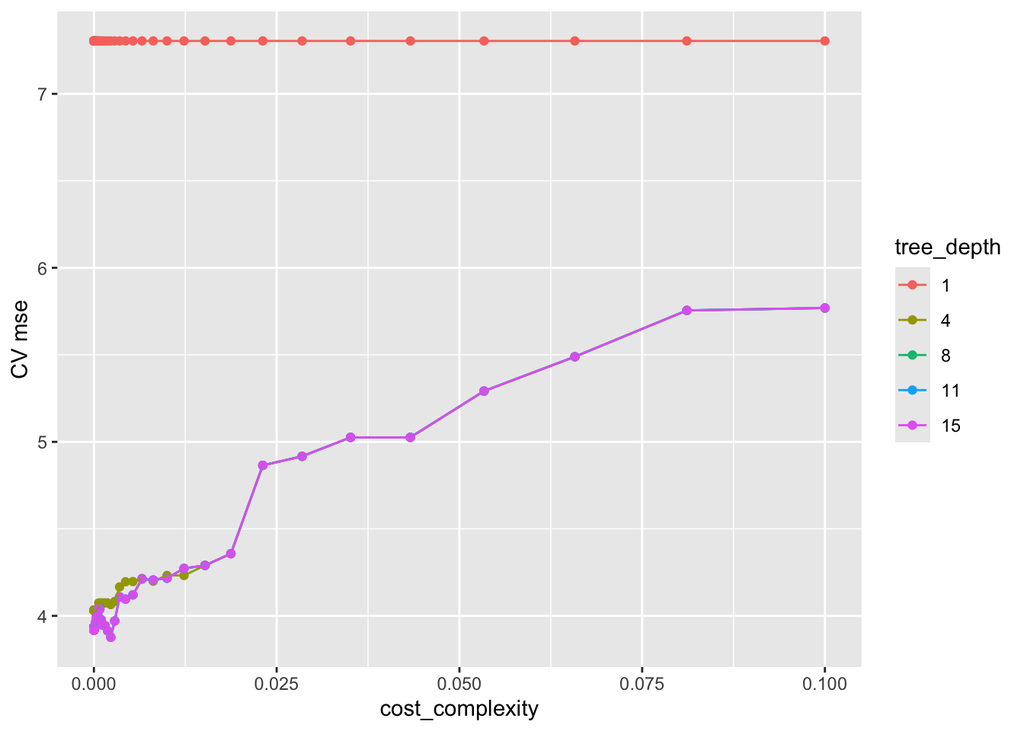

```r
# Visualize CV results
tree_fit %>%
  collect_metrics() %>%
  print(width = Inf) %>%
  filter(.metric == "rmse") %>%
  mutate(tree_depth = as.factor(tree_depth)) %>%
  ggplot(mapping = aes(x = cost_complexity, y = mean, color = tree_depth)) +
  geom_point() +
  geom_line() +
  labs(x = "cost_complexity", y = "CV mse")
```

Finalize the model

```r
tree_fit %>%
  show_best("rmse")
```

```
# A tibble: 5 × 8
  cost_complexity tree_depth .metric .estimator  mean     n std_err .config
            <dbl>      <int> <chr>   <chr>      <dbl> <int>   <dbl> <chr>
1         0.00231          8 rmse    standard    3.88     5   0.248 Preprocesso…
2         0.00231         11 rmse    standard    3.88     5   0.248 Preprocesso…
3         0.00231         15 rmse    standard    3.88     5   0.248 Preprocesso…
4         0.00187          8 rmse    standard    3.91     5   0.285 Preprocesso…
5         0.00187         11 rmse    standard    3.91     5   0.285 Preprocesso…
```

```r
best_tree <- tree_fit %>%
  select_best("rmse")
best_tree
```

```
# A tibble: 1 × 3
  cost_complexity tree_depth .config
            <dbl>      <int> <chr>
1         0.00231          8 Preprocessor1_Model282
```

```r
# Final workflow
final_wf_rt <- tree_wf_rt %>%
  finalize_workflow(best_tree)
final_wf_rt
```

```
══ Workflow ════════════════════════════════════════════════════════════════════
Preprocessor: Recipe
Model: decision_tree()

── Preprocessor ────────────────────────────────────────────────────────────────
4 Recipe Steps

• step_dummy()
• step_naomit()
• step_zv()
• step_normalize()

── Model ───────────────────────────────────────────────────────────────────────
Decision Tree Model Specification (regression)

Main Arguments:
  cost_complexity = 0.00231012970008316
  tree_depth = 8
  min_n = 5

Computational engine: rpart
```

```r
# Fit the whole training set, then predict the test cases
final_fit_rt <-
  final_wf_rt %>%
  last_fit(data_split)
final_fit_rt
```

```
# Resampling results
# Manual resampling
# A tibble: 1 × 6
  splits           id               .metrics .notes   .predictions .workflow
  <list>           <chr>            <list>   <list>   <list>       <list>
1 <split [455/51]> train/test split <tibble> <tibble> <tibble>     <workflow>
```

```r
# Test metrics
final_fit_rt %>%
  collect_metrics()
```

```
# A tibble: 2 × 4
  .metric .estimator .estimate .config
  <chr>   <chr>          <dbl> <chr>
1 rmse    standard       4.89  Preprocessor1_Model1
2 rsq     standard       0.641 Preprocessor1_Model1
```

Visualize the model

```r
library(rpart.plot)
final_tree <- extract_workflow(final_fit_rt)
final_tree
```

```
══ Workflow [trained] ══════════════════════════════════════════════════════════
Preprocessor: Recipe
Model: decision_tree()

── Preprocessor ────────────────────────────────────────────────────────────────
4 Recipe Steps

• step_dummy()
• step_naomit()
• step_zv()
• step_normalize()

── Model ───────────────────────────────────────────────────────────────────────
n= 455

node), split, n, deviance, yval
      * denotes terminal node

 1) root 455 39459.76000 22.549010
   2) rm< 0.9619964 390 16386.43000 19.947950
     4) lstat>=0.2252722 160  2959.75700 14.838120
       8) crim>=0.232238 72   814.22870 11.962500
        16) lstat>=0.9624551 44   440.20430 10.638640
          32) nox>=1.024004 31   143.35100  9.135484 *
          33) nox< 1.024004 13    59.78308 14.223080 *
        17) lstat< 0.9624551 28   175.72860 14.042860 *
       9) crim< 0.232238 88  1063.01300 17.190910
        18) nox>=-0.2115829 66   604.33940 16.230300
          36) lstat>=0.8455847 22   185.51450 14.145450
            72) indus>=2.238353 2     0.60500  7.550000 *
            73) indus< 2.238353 20    89.20950 14.805000 *
          37) lstat< 0.8455847 44   275.38730 17.272730 *
        19) nox< -0.2115829 22   215.06360 20.072730 *
     5) lstat< 0.2252722 230  6342.83800 23.502610
      10) dis>=-1.147931 225  3460.89800 23.012000
        20) rm< 0.3672057 172  1142.09700 21.526740
          40) lstat>=-0.7193731 138   730.12320 20.853620 *
          41) lstat< -0.7193731 34    95.66235 24.258820 *
        21) rm>=0.3672057 53   708.01550 27.832080
          42) lstat>=-0.9662533 29   219.12970 26.003450 *
          43) lstat< -0.9662533 24   274.73830 30.041670
            86) nox>=-0.2716461 2     0.72000 23.400000 *
            87) nox< -0.2716461 22   177.77450 30.645450 *
      11) dis< -1.147931 5   390.72800 45.580000
        22) crim>=0.5660168 2   244.20500 38.950000 *
        23) crim< 0.5660168 3     0.00000 50.000000 *
   3) rm>=0.9619964 65  4603.44100 38.155380
     6) rm< 1.619251 37  1048.25000 32.797300
      12) lstat>=-1.01397 20   518.31750 30.525000
        24) ptratio>=0.4363053 4   114.32750 23.425000 *
        25) ptratio< 0.4363053 16   151.94000 32.300000 *
      13) lstat< -1.01397 17   305.17530 35.470590
        26) dis>=-0.4841573 15    68.99600 34.340000 *
        27) dis< -0.4841573 2    73.20500 43.950000 *
     7) rm>=1.619251 28  1089.28400 45.235710
      14) ptratio>=-0.07153377 3   223.82000 33.300000 *
      15) ptratio< -0.07153377 25   386.79440 46.668000
        30) ptratio>=-1.687385 12   194.48000 44.400000 *
        31) ptratio< -1.687385 13    73.61077 48.761540 *
```

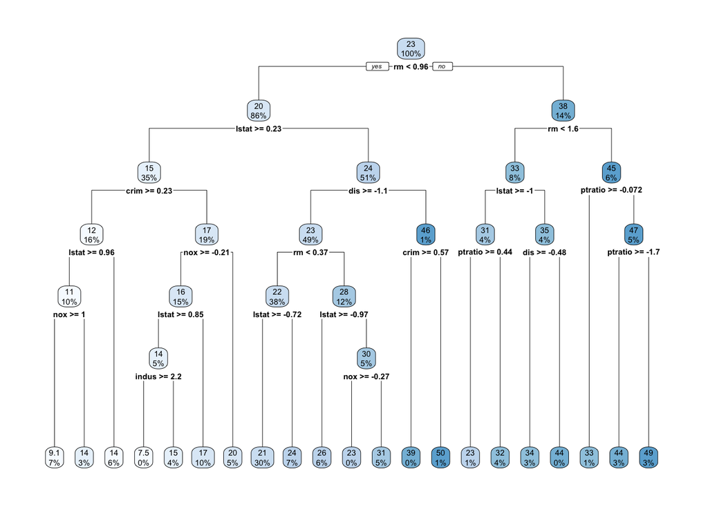

```r
final_tree %>%
  extract_fit_engine() %>%
  rpart.plot(roundint = FALSE)
```

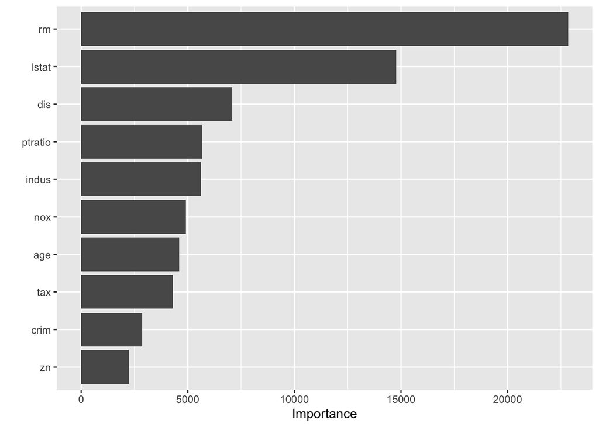

```r
library(vip)

final_tree %>%
  extract_fit_parsnip() %>%
  vip()
```

Model **Random forest:**

```r
rf_mod <-
  rand_forest(
    mode = "regression",
    # Number of predictors randomly sampled in each split
    mtry = tune(),
    # Number of trees in ensemble
    trees = tune()
  ) %>%
  set_engine("ranger")
rf_mod
```

```
Random Forest Model Specification (regression)

Main Arguments:
  mtry = tune()
  trees = tune()

Computational engine: ranger
```

Workflow

```r
rf_wf <- workflow() %>%
  add_recipe(tree_recipe) %>%
  add_model(rf_mod)
rf_wf
```

```
══ Workflow ════════════════════════════════════════════════════════════════════
Preprocessor: Recipe
Model: rand_forest()

── Preprocessor ────────────────────────────────────────────────────────────────
4 Recipe Steps

• step_dummy()
• step_naomit()
• step_zv()
• step_normalize()

── Model ───────────────────────────────────────────────────────────────────────
Random Forest Model Specification (regression)

Main Arguments:
  mtry = tune()
  trees = tune()

Computational engine: ranger
```

Tuning grid

```r
param_grid <- grid_regular(
  trees(range = c(100L, 300L)),
  mtry(range = c(1L, 5L)),
  levels = c(3, 5)
  )
param_grid
```

```
# A tibble: 15 × 2
   trees  mtry
   <int> <int>
 1   100     1
 2   200     1
 3   300     1
 4   100     2
 5   200     2
 6   300     2
 7   100     3
 8   200     3
 9   300     3
10   100     4
11   200     4
12   300     4
13   100     5
14   200     5
15   300     5
```

Cross-validation

```r
set.seed(1)

folds <- vfold_cv(Boston_other, v = 5)
folds
```

```
#  5-fold cross-validation
# A tibble: 5 × 2
  splits           id
  <list>           <chr>
1 <split [364/91]> Fold1
2 <split [364/91]> Fold2
3 <split [364/91]> Fold3
4 <split [364/91]> Fold4
5 <split [364/91]> Fold5
```

```r
# Fit cross-validation
rf_fit <- rf_wf %>%
  tune_grid(
    resamples = folds,
    grid = param_grid,
    metrics = metric_set(rmse, rsq)
    )
rf_fit
```

```
# Tuning results
# 5-fold cross-validation
# A tibble: 5 × 4
  splits           id    .metrics          .notes
  <list>           <chr> <list>            <list>
1 <split [364/91]> Fold1 <tibble [30 × 6]> <tibble [0 × 3]>
2 <split [364/91]> Fold2 <tibble [30 × 6]> <tibble [0 × 3]>
3 <split [364/91]> Fold3 <tibble [30 × 6]> <tibble [0 × 3]>
4 <split [364/91]> Fold4 <tibble [30 × 6]> <tibble [0 × 3]>
5 <split [364/91]> Fold5 <tibble [30 × 6]> <tibble [0 × 3]>
```

Visualize CV results:

```
# A tibble: 30 × 8
    mtry trees .metric .estimator  mean     n std_err .config
   <int> <int> <chr>   <chr>      <dbl> <int>   <dbl> <chr>
 1     1   100 rmse    standard   4.57      5  0.354  Preprocessor1_Model01
 2     1   100 rsq     standard   0.795     5  0.0517 Preprocessor1_Model01
 3     1   200 rmse    standard   4.59      5  0.316  Preprocessor1_Model02
 4     1   200 rsq     standard   0.794     5  0.0443 Preprocessor1_Model02
 5     1   300 rmse    standard   4.55      5  0.304  Preprocessor1_Model03
 6     1   300 rsq     standard   0.798     5  0.0452 Preprocessor1_Model03
 7     2   100 rmse    standard   3.67      5  0.347  Preprocessor1_Model04
 8     2   100 rsq     standard   0.855     5  0.0389 Preprocessor1_Model04
 9     2   200 rmse    standard   3.66      5  0.294  Preprocessor1_Model05
10     2   200 rsq     standard   0.859     5  0.0314 Preprocessor1_Model05
# ℹ 20 more rows
```

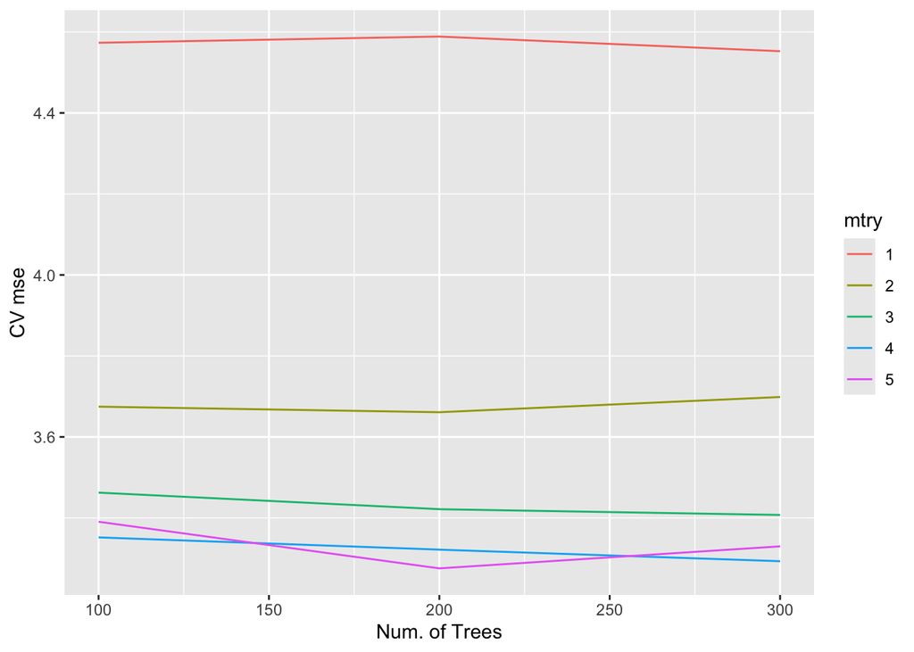

```r
rf_fit %>%
  collect_metrics() %>%
  print(width = Inf) %>%
  filter(.metric == "rmse") %>%
  mutate(mtry = as.factor(mtry)) %>%
  ggplot(mapping = aes(x = trees, y = mean, color = mtry)) +
  geom_line() +
  labs(x = "Num. of Trees", y = "CV mse")
```

```r
rf_fit %>%
  show_best("rmse")
```

```
# A tibble: 5 × 8
   mtry trees .metric .estimator  mean     n std_err .config
  <int> <int> <chr>   <chr>      <dbl> <int>   <dbl> <chr>
1     5   200 rmse    standard    3.28     5   0.300 Preprocessor1_Model14
2     4   300 rmse    standard    3.29     5   0.313 Preprocessor1_Model12
3     4   200 rmse    standard    3.32     5   0.300 Preprocessor1_Model11
4     5   300 rmse    standard    3.33     5   0.301 Preprocessor1_Model15
5     4   100 rmse    standard    3.35     5   0.298 Preprocessor1_Model10
```

```r
best_rf <- rf_fit %>%
  select_best("rmse")
best_rf
```

```
# A tibble: 1 × 3
   mtry trees .config
  <int> <int> <chr>
1     5   200 Preprocessor1_Model14
```

Finalize the model

```r
# Final workflow
final_wf <- rf_wf %>%
  finalize_workflow(best_rf)
final_wf
```

```
══ Workflow ════════════════════════════════════════════════════════════════════
Preprocessor: Recipe
Model: rand_forest()

── Preprocessor ────────────────────────────────────────────────────────────────
4 Recipe Steps

• step_dummy()
• step_naomit()
• step_zv()
• step_normalize()

── Model ───────────────────────────────────────────────────────────────────────
Random Forest Model Specification (regression)

Main Arguments:
  mtry = 5
  trees = 200

Computational engine: ranger
```

```r
# Fit the whole training set, then predict the test cases
final_fit <-
  final_wf %>%
  last_fit(data_split)
final_fit
```

```
# Resampling results
# Manual resampling
# A tibble: 1 × 6
  splits           id               .metrics .notes   .predictions .workflow
  <list>           <chr>            <list>   <list>   <list>       <list>
1 <split [455/51]> train/test split <tibble> <tibble> <tibble>     <workflow>
```

```r
# Test metrics
final_fit %>%
  collect_metrics()
```

```
# A tibble: 2 × 4
  .metric .estimator .estimate .config
  <chr>   <chr>          <dbl> <chr>
1 rmse    standard       3.56  Preprocessor1_Model1
2 rsq     standard       0.803 Preprocessor1_Model1
```

**Boosting:**

```r
gb_mod <-
  boost_tree(
    mode = "regression",
    trees = 1000,
    tree_depth = tune(),
    learn_rate = tune()
  ) %>%
  set_engine("xgboost")
gb_mod
```

```
Boosted Tree Model Specification (regression)

Main Arguments:
  trees = 1000
  tree_depth = tune()
  learn_rate = tune()

Computational engine: xgboost
```

Workflow

```r
gb_wf <- workflow() %>%
  add_recipe(tree_recipe) %>%
  add_model(gb_mod)
gb_wf
```

```
══ Workflow ════════════════════════════════════════════════════════════════════
Preprocessor: Recipe
Model: boost_tree()

── Preprocessor ────────────────────────────────────────────────────────────────
4 Recipe Steps

• step_dummy()
• step_naomit()
• step_zv()
• step_normalize()

── Model ───────────────────────────────────────────────────────────────────────
Boosted Tree Model Specification (regression)

Main Arguments:
  trees = 1000
  tree_depth = tune()
  learn_rate = tune()

Computational engine: xgboost
```

Tuning grid

```r
param_grid <- grid_regular(
  tree_depth(range = c(1L, 4L)),
  learn_rate(range = c(-3, -0.5), trans = log10_trans()),
  levels = c(4, 10)
  )
param_grid
```

```
# A tibble: 40 × 2
   tree_depth learn_rate
        <int>      <dbl>
 1          1    0.001
 2          2    0.001
 3          3    0.001
 4          4    0.001
 5          1    0.00190
 6          2    0.00190
 7          3    0.00190
 8          4    0.00190
 9          1    0.00359
10          2    0.00359
# ℹ 30 more rows
```

Cross-validation

```r
gb_fit <- gb_wf %>%
  tune_grid(
    resamples = folds,
    grid = param_grid,
    metrics = metric_set(rmse, rsq)
    )
gb_fit
```

```
# Tuning results
# 5-fold cross-validation
# A tibble: 5 × 4
  splits           id    .metrics          .notes
  <list>           <chr> <list>            <list>
1 <split [364/91]> Fold1 <tibble [80 × 6]> <tibble [0 × 3]>
2 <split [364/91]> Fold2 <tibble [80 × 6]> <tibble [0 × 3]>
3 <split [364/91]> Fold3 <tibble [80 × 6]> <tibble [0 × 3]>
4 <split [364/91]> Fold4 <tibble [80 × 6]> <tibble [0 × 3]>
5 <split [364/91]> Fold5 <tibble [80 × 6]> <tibble [0 × 3]>
```

Visualize CV results

[output not shown]

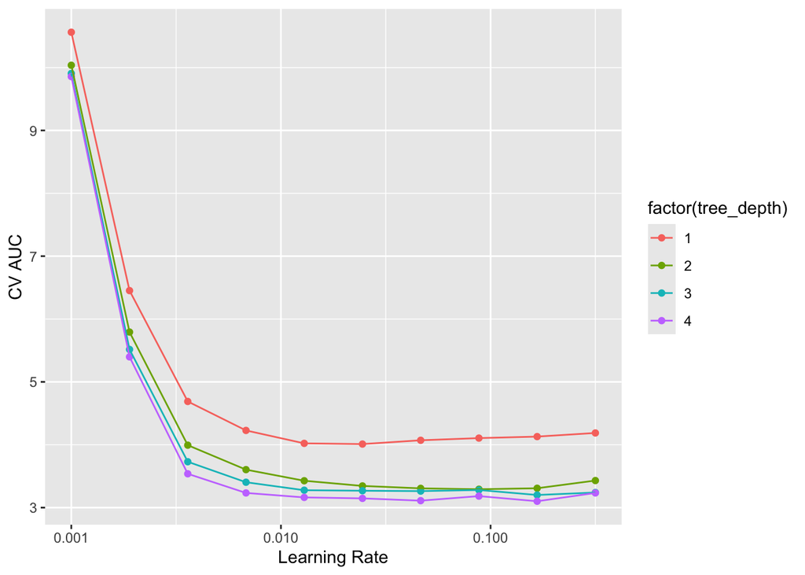

```r
gb_fit %>%
  collect_metrics() %>%
  print(width = Inf) %>%
  filter(.metric == "rmse") %>%
  ggplot(mapping = aes(x = learn_rate, y = mean, color = factor(tree_depth))) +
  geom_point() +
  geom_line() +
  labs(x = "Learning Rate", y = "CV AUC") +
  scale_x_log10()
```

Show the top 5 models

```r
gb_fit %>%
  show_best("rmse")
```

```
# A tibble: 5 × 8
  tree_depth learn_rate .metric .estimator  mean     n std_err .config
       <int>      <dbl> <chr>   <chr>      <dbl> <int>   <dbl> <chr>
1          4     0.167  rmse    standard    3.10     5   0.321 Preprocessor1_Mo…
2          4     0.0464 rmse    standard    3.11     5   0.290 Preprocessor1_Mo…
3          4     0.0245 rmse    standard    3.15     5   0.313 Preprocessor1_Mo…
4          4     0.0129 rmse    standard    3.16     5   0.329 Preprocessor1_Mo…
5          4     0.0880 rmse    standard    3.18     5   0.325 Preprocessor1_Mo…
```

Select the best model

```r
best_gb <- gb_fit %>%
  select_best("rmse")
best_gb
```

```
# A tibble: 1 × 3
  tree_depth learn_rate .config
       <int>      <dbl> <chr>
1          4      0.167 Preprocessor1_Model36
```

Finalize the model

```r
# Final workflow
final_wf <- gb_wf %>%
  finalize_workflow(best_gb)
final_wf
```

```
══ Workflow ════════════════════════════════════════════════════════════════════
Preprocessor: Recipe
Model: boost_tree()

── Preprocessor ────────────────────────────────────────────────────────────────
4 Recipe Steps

• step_dummy()
• step_naomit()
• step_zv()
• step_normalize()

── Model ───────────────────────────────────────────────────────────────────────
Boosted Tree Model Specification (regression)

Main Arguments:
  trees = 1000
  tree_depth = 4
  learn_rate = 0.166810053720006

Computational engine: xgboost
```

```r
# Fit the whole training set, then predict the test cases
final_fit <-
  final_wf %>%
  last_fit(data_split)
final_fit
```

```
# Resampling results
# Manual resampling
# A tibble: 1 × 6
  splits           id               .metrics .notes   .predictions .workflow
  <list>           <chr>            <list>   <list>   <list>       <list>
1 <split [455/51]> train/test split <tibble> <tibble> <tibble>     <workflow>
```

```r
# Test metrics
final_fit %>%
  collect_metrics()
```

```
# A tibble: 2 × 4
  .metric .estimator .estimate .config
  <chr>   <chr>          <dbl> <chr>
1 rmse    standard       3.18  Preprocessor1_Model1
2 rsq     standard       0.843 Preprocessor1_Model1
```

Overall, the tree model has RMSE of 4.8922, the random forest model has RMSE of 3.5607, and boosting model has RMSE of 3.1804. Therefore, for `Boston` data set, the boosting model has the best performance.

## 5 ISL Lab 8.3 `Carseats` data set (30pts)

Follow the machine learning workflow to train classification tree, random forest, and boosting methods for classifying `Sales <= 8` versus `Sales > 8`. Evaluate out-of-sample performance on a test set.

```r
Carseats <- Carseats %>%
  mutate(Sales = ifelse(Sales <= 8, "Low", "High"))
```

Initial split into test and non-test set

```r
set.seed(2)

data_split <- initial_split(
  Carseats,
  prop = 0.9,
  strata = Sales
  )
data_split
```

```
<Training/Testing/Total>
<359/41/400>
```

```r
Carseats_other <- training(data_split)
dim(Carseats_other)
```

```
[1] 359  11
```

```r
Carseats_test <- testing(data_split)
dim(Carseats_test)
```

```
[1] 41 11
```

Recipe

```r
tree_recipe <-
  recipe(
    Sales ~ .,
    data = Carseats_other
  ) %>%
  step_naomit(all_predictors()) %>%
  step_dummy(all_nominal_predictors()) %>%
  step_zv(all_numeric_predictors()) %>%
  step_normalize(all_numeric_predictors())
tree_recipe
```

Model **Classification tree:**

```r
classtree_mod <- decision_tree(
  cost_complexity = tune(),
  tree_depth = tune(),
  min_n = 5,
  mode = "classification",
  engine = "rpart"
  )
```

Workflow

```r
tree_wf <- workflow() %>%
  add_recipe(tree_recipe) %>%
  add_model(classtree_mod)
tree_wf
```

```
══ Workflow ════════════════════════════════════════════════════════════════════
Preprocessor: Recipe
Model: decision_tree()

── Preprocessor ────────────────────────────────────────────────────────────────
4 Recipe Steps

• step_naomit()
• step_dummy()
• step_zv()
• step_normalize()

── Model ───────────────────────────────────────────────────────────────────────
Decision Tree Model Specification (classification)

Main Arguments:
  cost_complexity = tune()
  tree_depth = tune()
  min_n = 5

Computational engine: rpart
```

Tuning grid

```r
tree_grid <- grid_regular(cost_complexity(),
                          tree_depth(),
                          levels = c(100,5))
tree_grid
```

```
# A tibble: 500 × 2
   cost_complexity tree_depth
             <dbl>      <int>
 1        1   e-10          1
 2        1.23e-10          1
 3        1.52e-10          1
 4        1.87e-10          1
 5        2.31e-10          1
 6        2.85e-10          1
 7        3.51e-10          1
 8        4.33e-10          1
 9        5.34e-10          1
10        6.58e-10          1
# ℹ 490 more rows
```

Cross-validation

```r
set.seed(2)
folds <- vfold_cv(Carseats_other, v = 5)
folds
```

```
#  5-fold cross-validation
# A tibble: 5 × 2
  splits           id
  <list>           <chr>
1 <split [287/72]> Fold1
2 <split [287/72]> Fold2
3 <split [287/72]> Fold3
4 <split [287/72]> Fold4
5 <split [288/71]> Fold5
```

```r
tree_fit <- tree_wf %>%
  tune_grid(
    resamples = folds,
    grid = tree_grid,
    metrics = metric_set(accuracy, roc_auc)
    )
tree_fit
```

```
# Tuning results
# 5-fold cross-validation
# A tibble: 5 × 4
  splits           id    .metrics             .notes
  <list>           <chr> <list>               <list>
1 <split [287/72]> Fold1 <tibble [1,000 × 6]> <tibble [0 × 3]>
2 <split [287/72]> Fold2 <tibble [1,000 × 6]> <tibble [0 × 3]>
3 <split [287/72]> Fold3 <tibble [1,000 × 6]> <tibble [0 × 3]>
4 <split [287/72]> Fold4 <tibble [1,000 × 6]> <tibble [0 × 3]>
5 <split [288/71]> Fold5 <tibble [1,000 × 6]> <tibble [0 × 3]>
```

Visualize CV results

```
# A tibble: 1,000 × 8
   cost_complexity tree_depth .metric  .estimator  mean     n std_err
             <dbl>      <int> <chr>    <chr>      <dbl> <int>   <dbl>
 1        1   e-10          1 accuracy binary     0.719     5  0.0221
 2        1   e-10          1 roc_auc  binary     0.673     5  0.0171
 3        1.23e-10          1 accuracy binary     0.719     5  0.0221
 4        1.23e-10          1 roc_auc  binary     0.673     5  0.0171
 5        1.52e-10          1 accuracy binary     0.719     5  0.0221
 6        1.52e-10          1 roc_auc  binary     0.673     5  0.0171
 7        1.87e-10          1 accuracy binary     0.719     5  0.0221
 8        1.87e-10          1 roc_auc  binary     0.673     5  0.0171
 9        2.31e-10          1 accuracy binary     0.719     5  0.0221
10        2.31e-10          1 roc_auc  binary     0.673     5  0.0171
   .config
   <chr>
 1 Preprocessor1_Model001
 2 Preprocessor1_Model001
 3 Preprocessor1_Model002
 4 Preprocessor1_Model002
 5 Preprocessor1_Model003
 6 Preprocessor1_Model003
 7 Preprocessor1_Model004
 8 Preprocessor1_Model004
 9 Preprocessor1_Model005
10 Preprocessor1_Model005
# ℹ 990 more rows
```

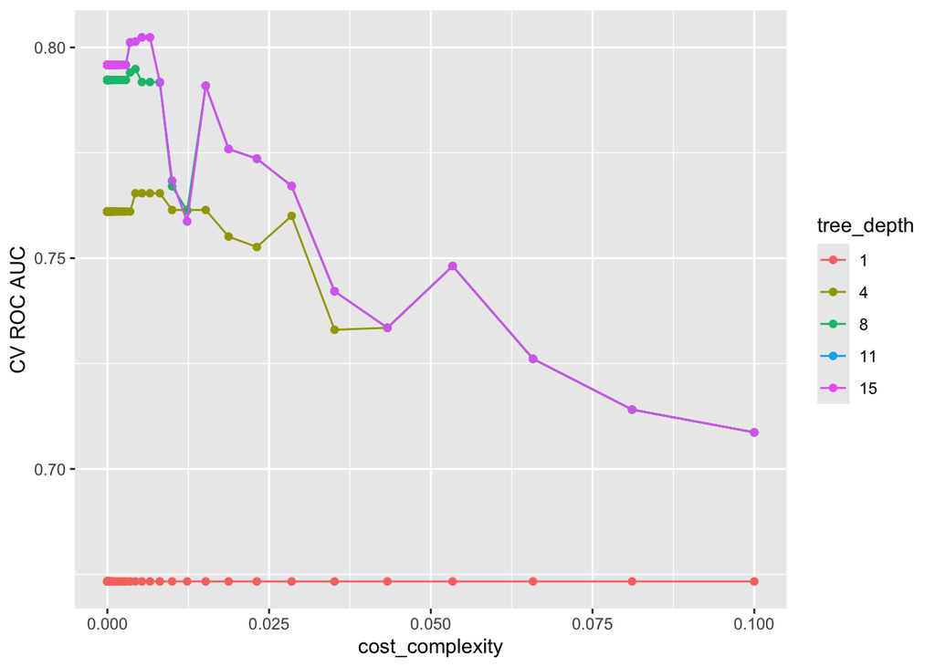

```r
tree_fit %>%
  collect_metrics() %>%
  print(width = Inf) %>%
  filter(.metric == "roc_auc") %>%
  mutate(tree_depth = as.factor(tree_depth)) %>%
  ggplot(mapping = aes(x = cost_complexity, y = mean, color = tree_depth)) +
  geom_point() +
  geom_line() +
  labs(x = "cost_complexity", y = "CV ROC AUC", color = "tree_depth")
```

Finalize the model

```r
tree_fit %>%
  show_best("roc_auc")
```

```
# A tibble: 5 × 8
  cost_complexity tree_depth .metric .estimator  mean     n std_err .config
            <dbl>      <int> <chr>   <chr>      <dbl> <int>   <dbl> <chr>
1         0.00534         11 roc_auc binary     0.802     5  0.0186 Preprocesso…
2         0.00658         11 roc_auc binary     0.802     5  0.0186 Preprocesso…
3         0.00534         15 roc_auc binary     0.802     5  0.0186 Preprocesso…
4         0.00658         15 roc_auc binary     0.802     5  0.0186 Preprocesso…
5         0.00433         11 roc_auc binary     0.801     5  0.0188 Preprocesso…
```

```r
best_tree <- tree_fit %>%
  select_best("roc_auc")
best_tree
```

```
# A tibble: 1 × 3
  cost_complexity tree_depth .config
            <dbl>      <int> <chr>
1         0.00534         11 Preprocessor1_Model386
```

```r
# Final workflow
final_wf <- tree_wf %>%
  finalize_workflow(best_tree)
final_wf
```

```
══ Workflow ════════════════════════════════════════════════════════════════════
Preprocessor: Recipe
Model: decision_tree()

── Preprocessor ────────────────────────────────────────────────────────────────
4 Recipe Steps

• step_naomit()
• step_dummy()
• step_zv()
• step_normalize()

── Model ───────────────────────────────────────────────────────────────────────
Decision Tree Model Specification (classification)

Main Arguments:
  cost_complexity = 0.00533669923120631
  tree_depth = 11
  min_n = 5

Computational engine: rpart
```

```r
# Fit the whole training set, then predict the test cases
final_fit <-
  final_wf %>%
  last_fit(data_split)
final_fit
```

```
# Resampling results
# Manual resampling
# A tibble: 1 × 6
  splits           id               .metrics .notes   .predictions .workflow
  <list>           <chr>            <list>   <list>   <list>       <list>
1 <split [359/41]> train/test split <tibble> <tibble> <tibble>     <workflow>
```

```r
# Test metrics
final_fit %>%
  collect_metrics()
```

```
# A tibble: 2 × 4
  .metric  .estimator .estimate .config
  <chr>    <chr>          <dbl> <chr>
1 accuracy binary         0.805 Preprocessor1_Model1
2 roc_auc  binary         0.836 Preprocessor1_Model1
```

Visualize the final model

```r
library(rpart.plot)
final_tree <- extract_workflow(final_fit)
final_tree
```

```
══ Workflow [trained] ══════════════════════════════════════════════════════════
Preprocessor: Recipe
Model: decision_tree()

── Preprocessor ────────────────────────────────────────────────────────────────
4 Recipe Steps

• step_naomit()
• step_dummy()
• step_zv()
• step_normalize()

── Model ───────────────────────────────────────────────────────────────────────
n= 359

node), split, n, loss, yval, (yprob)
      * denotes terminal node

  1) root 359 147 Low (0.40947075 0.59052925)
    2) ShelveLoc_Good>=0.7467849 72  13 High (0.81944444 0.18055556)
      4) Price< 0.8119527 58   4 High (0.93103448 0.06896552)
        8) US_Yes>=-0.2990822 44   0 High (1.00000000 0.00000000) *
        9) US_Yes< -0.2990822 14   4 High (0.71428571 0.28571429)
         18) Price< -0.2764814 7   0 High (1.00000000 0.00000000) *
         19) Price>=-0.2764814 7   3 Low (0.42857143 0.57142857)
           38) CompPrice>=0.2972255 3   0 High (1.00000000 0.00000000) *
           39) CompPrice< 0.2972255 4   0 Low (0.00000000 1.00000000) *
      5) Price>=0.8119527 14   5 Low (0.35714286 0.64285714)
       10) Income>=-0.7837747 8   3 High (0.62500000 0.37500000)
         20) Education>=-0.3397437 5   0 High (1.00000000 0.00000000) *
         21) Education< -0.3397437 3   0 Low (0.00000000 1.00000000) *
       11) Income< -0.7837747 6   0 Low (0.00000000 1.00000000) *
    3) ShelveLoc_Good< 0.7467849 287  88 Low (0.30662021 0.69337979)
      6) Price< -0.9672184 42  13 High (0.69047619 0.30952381)
       12) Income>=-1.279216 39  10 High (0.74358974 0.25641026)
         24) ShelveLoc_Medium>=-0.1034714 25   4 High (0.84000000 0.16000000)
           48) Age< 0.6838563 18   1 High (0.94444444 0.05555556) *
           49) Age>=0.6838563 7   3 High (0.57142857 0.42857143)
             98) Population>=-0.1255032 3   0 High (1.00000000 0.00000000) *
             99) Population< -0.1255032 4   1 Low (0.25000000 0.75000000) *
```

[output cut: 11 more lines]

```
           56) ShelveLoc_Medium>=-0.1034714 18   1 High (0.94444444 0.05555556) *
           57) ShelveLoc_Medium< -0.1034714 6   2 Low (0.33333333 0.66666667)
            114) Income>=0.5432995 3   1 High (0.66666667 0.33333333) *
            115) Income< 0.5432995 3   0 Low (0.00000000 1.00000000) *
         29) CompPrice< -0.2187199 14   4 Low (0.28571429 0.71428571)
           58) Age< -0.6296549 5   1 High (0.80000000 0.20000000) *
           59) Age>=-0.6296549 9   0 Low (0.00000000 1.00000000) *
       15) Advertising< 1.053935 207  36 Low (0.17391304 0.82608696)
         30) CompPrice>=-0.02524036 119  31 Low (0.26050420 0.73949580)
           60) Price< 0.2886671 44  22 High (0.50000000 0.50000000)
            120) Age< -0.2325469 21   6 High (0.71428571 0.28571429)
              240) Population< 0.8630426 17   3 High (0.82352941 0.17647059)

...
and 24 more lines.
```

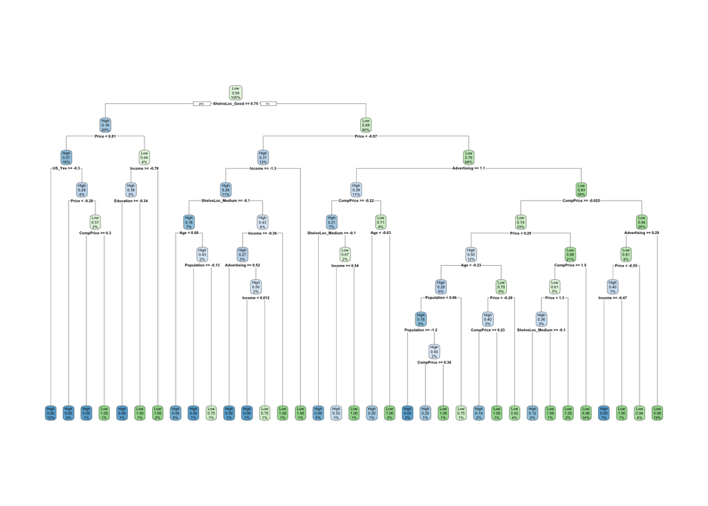

```r
final_tree %>%
  extract_fit_engine() %>%
  rpart.plot(roundint = FALSE)
```

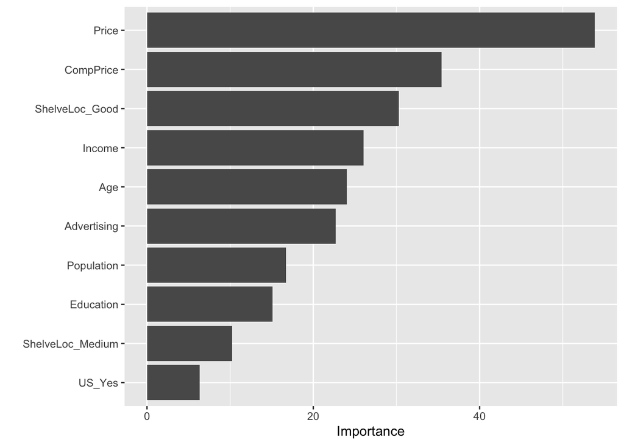

```r
library(vip)

final_tree %>%
  extract_fit_parsnip() %>%
  vip()
```

**Random forest:**

```r
rf_mod <-
  rand_forest(
    mode = "classification",
    # Number of predictors randomly sampled in each split
    mtry = tune(),
    # Number of trees in ensemble
    trees = tune()
  ) %>%
  set_engine("ranger")
rf_mod
```

```
Random Forest Model Specification (classification)

Main Arguments:
  mtry = tune()
  trees = tune()

Computational engine: ranger
```

Workflow

```r
rf_wf <- workflow() %>%
  add_recipe(tree_recipe) %>%
  add_model(rf_mod)
rf_wf
```

```
══ Workflow ════════════════════════════════════════════════════════════════════
Preprocessor: Recipe
Model: rand_forest()

── Preprocessor ────────────────────────────────────────────────────────────────
4 Recipe Steps

• step_naomit()
• step_dummy()
• step_zv()
• step_normalize()

── Model ───────────────────────────────────────────────────────────────────────
Random Forest Model Specification (classification)

Main Arguments:
  mtry = tune()
  trees = tune()

Computational engine: ranger
```

Tuning grid

```r
param_grid <- grid_regular(
  trees(range = c(100L, 300L)),
  mtry(range = c(1L, 5L)),
  levels = c(3, 5)
  )
param_grid
```

```
# A tibble: 15 × 2
   trees  mtry
   <int> <int>
 1   100     1
 2   200     1
 3   300     1
 4   100     2
 5   200     2
 6   300     2
 7   100     3
 8   200     3
 9   300     3
10   100     4
11   200     4
12   300     4
13   100     5
14   200     5
15   300     5
```

Cross-validation

```r
set.seed(2)

folds <- vfold_cv(Carseats_other, v = 5)
folds
```

```
#  5-fold cross-validation
# A tibble: 5 × 2
  splits           id
  <list>           <chr>
1 <split [287/72]> Fold1
2 <split [287/72]> Fold2
3 <split [287/72]> Fold3
4 <split [287/72]> Fold4
5 <split [288/71]> Fold5
```

```r
rf_fit <- rf_wf %>%
  tune_grid(
    resamples = folds,
    grid = param_grid,
    metrics = metric_set(roc_auc, accuracy)
    )
rf_fit
```

```
# Tuning results
# 5-fold cross-validation
# A tibble: 5 × 4
  splits           id    .metrics          .notes
  <list>           <chr> <list>            <list>
1 <split [287/72]> Fold1 <tibble [30 × 6]> <tibble [0 × 3]>
2 <split [287/72]> Fold2 <tibble [30 × 6]> <tibble [0 × 3]>
3 <split [287/72]> Fold3 <tibble [30 × 6]> <tibble [0 × 3]>
4 <split [287/72]> Fold4 <tibble [30 × 6]> <tibble [0 × 3]>
5 <split [288/71]> Fold5 <tibble [30 × 6]> <tibble [0 × 3]>
```

Visualize CV results

```
# A tibble: 30 × 8
    mtry trees .metric  .estimator  mean     n std_err .config
   <int> <int> <chr>    <chr>      <dbl> <int>   <dbl> <chr>
 1     1   100 accuracy binary     0.766     5  0.0252 Preprocessor1_Model01
 2     1   100 roc_auc  binary     0.841     5  0.0183 Preprocessor1_Model01
 3     1   200 accuracy binary     0.783     5  0.0216 Preprocessor1_Model02
 4     1   200 roc_auc  binary     0.865     5  0.0135 Preprocessor1_Model02
 5     1   300 accuracy binary     0.766     5  0.0191 Preprocessor1_Model03
 6     1   300 roc_auc  binary     0.862     5  0.0129 Preprocessor1_Model03
 7     2   100 accuracy binary     0.783     5  0.0271 Preprocessor1_Model04
 8     2   100 roc_auc  binary     0.876     5  0.0135 Preprocessor1_Model04
 9     2   200 accuracy binary     0.799     5  0.0218 Preprocessor1_Model05
10     2   200 roc_auc  binary     0.883     5  0.0104 Preprocessor1_Model05
# ℹ 20 more rows
```

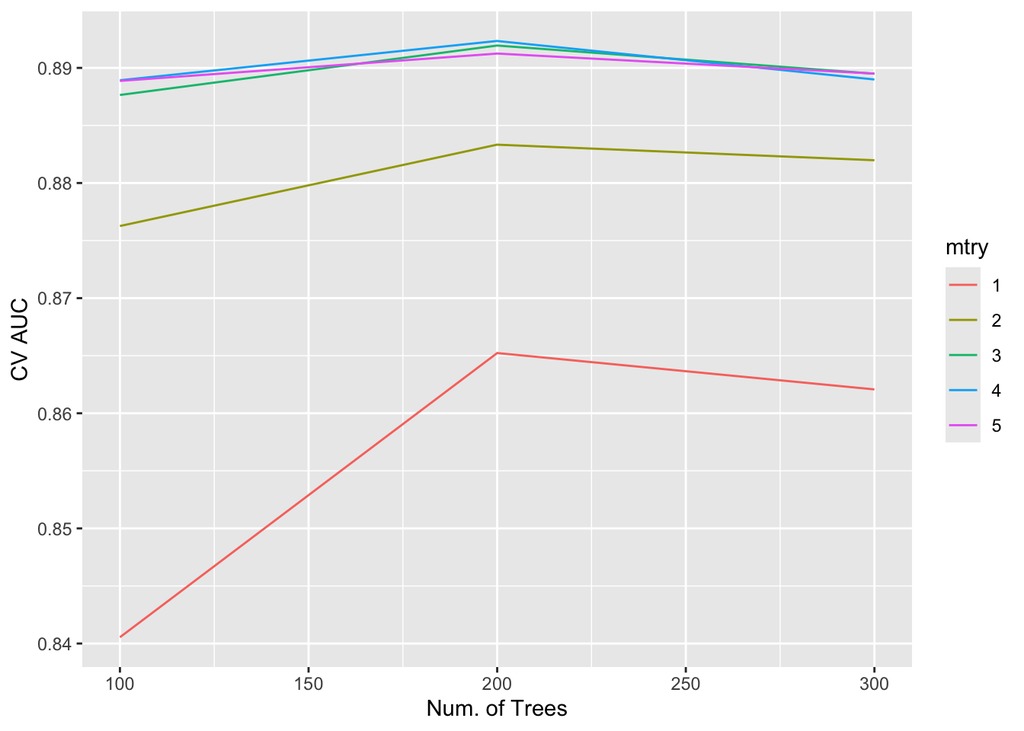

```r
rf_fit %>%
  collect_metrics() %>%
  print(width = Inf) %>%
  filter(.metric == "roc_auc") %>%
  mutate(mtry = as.factor(mtry)) %>%
  ggplot(mapping = aes(x = trees, y = mean, color = mtry)) +
  # geom_point() +
  geom_line() +
  labs(x = "Num. of Trees", y = "CV AUC")
```

Show the top 5 models

```r
rf_fit %>%
  show_best("roc_auc")
```

```
# A tibble: 5 × 8
   mtry trees .metric .estimator  mean     n std_err .config
  <int> <int> <chr>   <chr>      <dbl> <int>   <dbl> <chr>
1     4   200 roc_auc binary     0.892     5 0.00854 Preprocessor1_Model11
2     3   200 roc_auc binary     0.892     5 0.00540 Preprocessor1_Model08
3     5   200 roc_auc binary     0.891     5 0.00704 Preprocessor1_Model14
4     5   300 roc_auc binary     0.890     5 0.00600 Preprocessor1_Model15
5     3   300 roc_auc binary     0.889     5 0.00803 Preprocessor1_Model09
```

Select the best model

```r
best_rf <- rf_fit %>%
  select_best("roc_auc")
best_rf
```

```
# A tibble: 1 × 3
   mtry trees .config
  <int> <int> <chr>
1     4   200 Preprocessor1_Model11
```

Finalize the model

```r
# Final workflow
final_wf <- rf_wf %>%
  finalize_workflow(best_rf)
final_wf
```

```
══ Workflow ════════════════════════════════════════════════════════════════════
Preprocessor: Recipe
Model: rand_forest()

── Preprocessor ────────────────────────────────────────────────────────────────
4 Recipe Steps

• step_naomit()
• step_dummy()
• step_zv()
• step_normalize()

── Model ───────────────────────────────────────────────────────────────────────
Random Forest Model Specification (classification)

Main Arguments:
  mtry = 4
  trees = 200

Computational engine: ranger
```

```r
# Fit the whole training set, then predict the test cases
final_fit <-
  final_wf %>%
  last_fit(data_split)
final_fit
```

```
# Resampling results
# Manual resampling
# A tibble: 1 × 6
  splits           id               .metrics .notes   .predictions .workflow
  <list>           <chr>            <list>   <list>   <list>       <list>
1 <split [359/41]> train/test split <tibble> <tibble> <tibble>     <workflow>
```

```r
# Test metrics
final_fit %>%
  collect_metrics()
```

```
# A tibble: 2 × 4
  .metric  .estimator .estimate .config
  <chr>    <chr>          <dbl> <chr>
1 accuracy binary         0.854 Preprocessor1_Model1
2 roc_auc  binary         0.897 Preprocessor1_Model1
```

Model **Boosting:**

```r
gb_mod <-
  boost_tree(
    mode = "classification",
    trees = 1000,
    tree_depth = tune(),
    learn_rate = tune()
  ) %>%
  set_engine("xgboost")
gb_mod
```

```
Boosted Tree Model Specification (classification)

Main Arguments:
  trees = 1000
  tree_depth = tune()
  learn_rate = tune()

Computational engine: xgboost
```

Workflow

```r
gb_wf <- workflow() %>%
  add_recipe(tree_recipe) %>%
  add_model(gb_mod)
gb_wf
```

```
══ Workflow ════════════════════════════════════════════════════════════════════
Preprocessor: Recipe
Model: boost_tree()

── Preprocessor ────────────────────────────────────────────────────────────────
4 Recipe Steps

• step_naomit()
• step_dummy()
• step_zv()
• step_normalize()

── Model ───────────────────────────────────────────────────────────────────────
Boosted Tree Model Specification (classification)

Main Arguments:
  trees = 1000
  tree_depth = tune()
  learn_rate = tune()

Computational engine: xgboost
```

Tuning grid

```r
param_grid <- grid_regular(
  tree_depth(range = c(1L, 3L)),
  learn_rate(range = c(-5, 2), trans = log10_trans()),
  levels = c(3, 10)
  )
param_grid
```

```
# A tibble: 30 × 2
   tree_depth learn_rate
        <int>      <dbl>
 1          1  0.00001
 2          2  0.00001
 3          3  0.00001
 4          1  0.0000599
 5          2  0.0000599
 6          3  0.0000599
 7          1  0.000359
 8          2  0.000359
 9          3  0.000359
10          1  0.00215
# ℹ 20 more rows
```

Cross-validation

```r
gb_fit <- gb_wf %>%
  tune_grid(
    resamples = folds,
    grid = param_grid,
    metrics = metric_set(roc_auc, accuracy)
    )
gb_fit
```

```
# Tuning results
# 5-fold cross-validation
# A tibble: 5 × 4
  splits           id    .metrics          .notes
  <list>           <chr> <list>            <list>
1 <split [287/72]> Fold1 <tibble [60 × 6]> <tibble [0 × 3]>
2 <split [287/72]> Fold2 <tibble [60 × 6]> <tibble [0 × 3]>
3 <split [287/72]> Fold3 <tibble [60 × 6]> <tibble [0 × 3]>
4 <split [287/72]> Fold4 <tibble [60 × 6]> <tibble [0 × 3]>
5 <split [288/71]> Fold5 <tibble [60 × 6]> <tibble [0 × 3]>
```

Visualize CV results

```
# A tibble: 60 × 8
   tree_depth learn_rate .metric  .estimator  mean     n std_err
        <int>      <dbl> <chr>    <chr>      <dbl> <int>   <dbl>
 1          1  0.00001   accuracy binary     0.719     5 0.0221
 2          1  0.00001   roc_auc  binary     0.673     5 0.0171
 3          2  0.00001   accuracy binary     0.732     5 0.0230
 4          2  0.00001   roc_auc  binary     0.739     5 0.00770
 5          3  0.00001   accuracy binary     0.772     5 0.0176
 6          3  0.00001   roc_auc  binary     0.799     5 0.0142
 7          1  0.0000599 accuracy binary     0.719     5 0.0221
 8          1  0.0000599 roc_auc  binary     0.673     5 0.0171
 9          2  0.0000599 accuracy binary     0.732     5 0.0230
10          2  0.0000599 roc_auc  binary     0.740     5 0.00787
   .config
   <chr>
 1 Preprocessor1_Model01
 2 Preprocessor1_Model01
 3 Preprocessor1_Model02
 4 Preprocessor1_Model02
 5 Preprocessor1_Model03
 6 Preprocessor1_Model03
 7 Preprocessor1_Model04
 8 Preprocessor1_Model04
 9 Preprocessor1_Model05
10 Preprocessor1_Model05
# ℹ 50 more rows
```

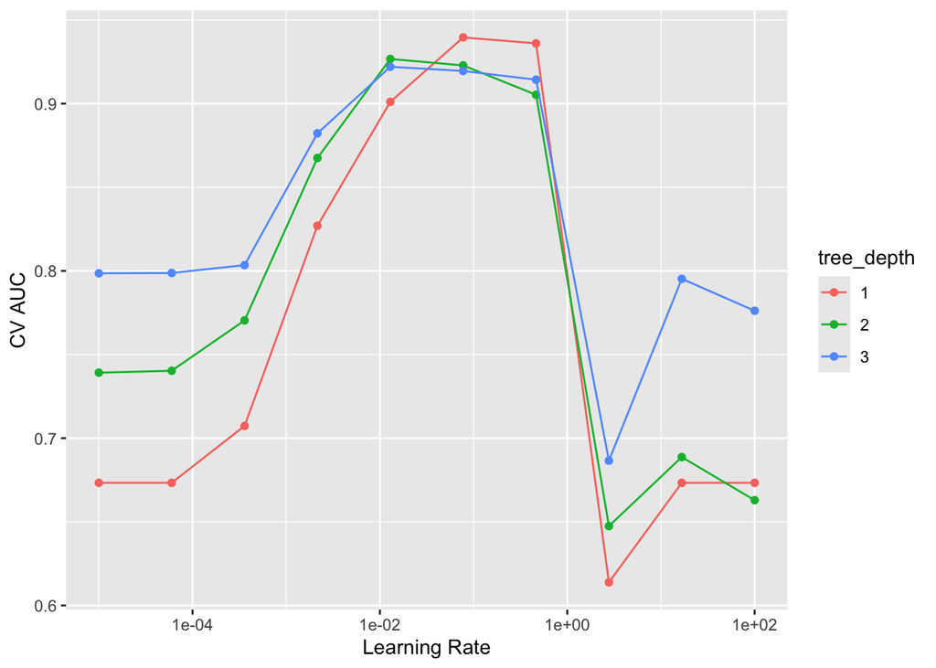

```r
gb_fit %>%
  collect_metrics() %>%
  print(width = Inf) %>%
  filter(.metric == "roc_auc") %>%
  mutate(tree_depth = as.factor(tree_depth)) %>%
  ggplot(mapping = aes(x = learn_rate, y = mean, color = tree_depth)) +
  geom_point() +
  geom_line() +
  labs(x = "Learning Rate", y = "CV AUC") +
  scale_x_log10()
```

Show the top 5 models

```r
gb_fit %>%
  show_best("roc_auc")
```

```
# A tibble: 5 × 8
  tree_depth learn_rate .metric .estimator  mean     n std_err .config
       <int>      <dbl> <chr>   <chr>      <dbl> <int>   <dbl> <chr>
1          1     0.0774 roc_auc binary     0.940     5 0.00914 Preprocessor1_Mo…
2          1     0.464  roc_auc binary     0.936     5 0.00633 Preprocessor1_Mo…
3          2     0.0129 roc_auc binary     0.927     5 0.0105  Preprocessor1_Mo…
4          2     0.0774 roc_auc binary     0.923     5 0.0128  Preprocessor1_Mo…
5          3     0.0129 roc_auc binary     0.922     5 0.00970 Preprocessor1_Mo…
```

Select the best model

```r
best_gb <- gb_fit %>%
  select_best("roc_auc")
best_gb
```

```
# A tibble: 1 × 3
  tree_depth learn_rate .config
       <int>      <dbl> <chr>
1          1     0.0774 Preprocessor1_Model16
```

Finalize the model

```r
# Final workflow
final_wf <- gb_wf %>%
  finalize_workflow(best_gb)
final_wf
```

```
══ Workflow ════════════════════════════════════════════════════════════════════
Preprocessor: Recipe
Model: boost_tree()

── Preprocessor ────────────────────────────────────────────────────────────────
4 Recipe Steps

• step_naomit()
• step_dummy()
• step_zv()
• step_normalize()

── Model ───────────────────────────────────────────────────────────────────────
Boosted Tree Model Specification (classification)

Main Arguments:
  trees = 1000
  tree_depth = 1
  learn_rate = 0.0774263682681127

Computational engine: xgboost
```

```r
# Fit the whole training set, then predict the test cases
final_fit <-
  final_wf %>%
  last_fit(data_split)
final_fit
```

```
# Resampling results
# Manual resampling
# A tibble: 1 × 6
  splits           id               .metrics .notes   .predictions .workflow
  <list>           <chr>            <list>   <list>   <list>       <list>
1 <split [359/41]> train/test split <tibble> <tibble> <tibble>     <workflow>
```

```r
# Test metrics
final_fit %>%
  collect_metrics()
```

```
# A tibble: 2 × 4
  .metric  .estimator .estimate .config
  <chr>    <chr>          <dbl> <chr>
1 accuracy binary         0.854 Preprocessor1_Model1
2 roc_auc  binary         0.958 Preprocessor1_Model1
```